# HW3

DACSS-603

Katie Popiela  
4/14/2022

### Question 1

**(SMSS 11.2, except part (d))**

**For recent data in Jacksonville, Florida, on y = selling price of home (in dollars), x1 = size of home (in square feet), and x2 = lot size (in square feet), the prediction equation is ŷ = −10,536 + 53.8x1 + 2.84x2**

**A particular home of 1240 square feet on a lot of 18,000 square feet sold for $145,000. Find the predicted selling price and the residual, and interpret.**

```r
predicted_price<--10536+53.8*1240+2.84*18000
predicted_price
```

```
[1] 107296
```

Given the variable information above (y=selling price, x1=house size, x2=lot size) as well as the data in the prediction equation (1,240 sqft house on a 18,000 sqft lot), the predicted selling price of the home is therefore $107,296. Now to calculate the residual between this and the actual selling price ($145,000).

```r
residual<-145000-predicted_price
residual
```

```
[1] 37704
```

**For fixed lot size, how much is the house selling price predicted to increase for each square-foot increase in home size? Why?**

Since the coefficient for home size is 53.8x1, the price of the home would go up $53.80 for each sqft increase in home size.

**According to this prediction equation, for fixed home size, how much would lot size need to increase to have the same impact as a one-square-foot increase in home size?**

Since the coefficient for lot size is 2.84x2, every sqft increase would add $2.84 to the overall price of the home. However (with lot size) to achieve the same impact as the price increase of home size, we need to do some simple division.

```r
53.8/2.84
```

```
[1] 18.94366
```

As the math shows, the lot size would need to increase by 18.9 sqft in order to have the same impact as an increase of 1 sqft of home space.

### Question 2

*(ALR, 5.17, slightly modified)*

**(Data file: salary in alr4 R package). The data file concerns salary and other characteristics of all faculty in a small Midwestern college collected in the early 1980s for presentation in legal proceedings for which discrimination against women in salary was at issue. All persons in the data hold tenured or tenure track positions; temporary faculty are not included. The variables include degree, a factor with levels PhD and MS; rank, a factor with levels Asst, Assoc, and Prof; sex, a factor with levels Male and Female; Year, years in current rank; ysdeg, years since highest degree, and salary, academic year salary in dollars.**

**A. Test the hypothesis that the mean salary for men and women is the same, without regard to any other variable but sex. Explain your findings.**

```r
library(alr4)
data("salary")
?salary
head(salary)
```

```
   degree rank    sex year ysdeg salary
1 Masters Prof   Male   25    35  36350
2 Masters Prof   Male   13    22  35350
3 Masters Prof   Male   10    23  28200
4 Masters Prof Female    7    27  26775
5     PhD Prof   Male   19    30  33696
6 Masters Prof   Male   16    21  28516
```

```r
summary(salary)
```

```
     degree      rank        sex          year            ysdeg
 Masters:34   Asst :18   Male  :38   Min.   : 0.000   Min.   : 1.00
 PhD    :18   Assoc:14   Female:14   1st Qu.: 3.000   1st Qu.: 6.75
              Prof :20               Median : 7.000   Median :15.50
                                     Mean   : 7.481   Mean   :16.12
                                     3rd Qu.:11.000   3rd Qu.:23.25
                                     Max.   :25.000   Max.   :35.00
     salary
 Min.   :15000
 1st Qu.:18247
 Median :23719
 Mean   :23798
 3rd Qu.:27259
 Max.   :38045
```

Now I will filter the dataset down to focus on sex and salary.

```r
data("salary")
t.test(salary~sex,data=salary)
```

```
    Welch Two Sample t-test

data:  salary by sex
t = 1.7744, df = 21.591, p-value = 0.09009
alternative hypothesis: true difference in means between group Male and group Female is not equal to 0
95 percent confidence interval:
 -567.8539 7247.1471
sample estimates:
  mean in group Male mean in group Female
            24696.79             21357.14
```

```r
24696.79-21357.14
```

```
[1] 3339.65
```

Without regard to education level and job rank, the mean salary for males is $24,696.79 whereas the mean salary for females is $21,357.14 – a $3,339.65 difference.

**B. Run a multiple linear regression with salary as the outcome variable and everything else as predictors, including sex. Assuming no interactions between sex and the other predictors, obtain a 95% confidence interval for the difference in salary between males and females.**

```r
fit <- lm(salary~degree+rank+sex+year+ysdeg,data=salary)

head(predict(fit), n=10)
```

```
       1        2        3        4        5        6        7
34412.44 30316.19 28762.69 28001.84 33566.07 31869.70 25433.42
       8        9       10
32243.42 30708.21 30583.64
```

```r
set.seed(3)
df<- data.frame(degree = sample(salary$degree, size = 10, replace = T),
                rank = sample(salary$rank, size = 10, replace = T),
                sex = sample(salary$sex, size = 10, replace = T),
                year = sample(salary$year, size = 10, replace = T),
                ysdeg = sample(salary$ysdeg, size = 10, replace = T))
predict(fit,df)
```

```
       1        2        3        4        5        6        7
15368.63 20671.56 14287.78 29407.55 20069.45 32082.22 23606.80
       8        9       10
16837.87 21524.03 28077.52
```

```r
summary(fit)
```

```
Call:
lm(formula = salary ~ degree + rank + sex + year + ysdeg, data = salary)

Residuals:
    Min      1Q  Median      3Q     Max
-4045.2 -1094.7  -361.5   813.2  9193.1

Coefficients:
            Estimate Std. Error t value Pr(>|t|)
(Intercept) 15746.05     800.18  19.678  < 2e-16 ***
degreePhD    1388.61    1018.75   1.363    0.180
rankAssoc    5292.36    1145.40   4.621 3.22e-05 ***
rankProf    11118.76    1351.77   8.225 1.62e-10 ***
sexFemale    1166.37     925.57   1.260    0.214
year          476.31      94.91   5.018 8.65e-06 ***
ysdeg        -124.57      77.49  -1.608    0.115
---
Signif. codes:  0 '***' 0.001 '**' 0.01 '*' 0.05 '.' 0.1 ' ' 1

Residual standard error: 2398 on 45 degrees of freedom
Multiple R-squared:  0.855, Adjusted R-squared:  0.8357
F-statistic: 44.24 on 6 and 45 DF,  p-value: < 2.2e-16
```

```r
confint(fit,'sexFemale')
```

```
              2.5 %   97.5 %
sexFemale -697.8183 3030.565
```

After running a multiple linear regression and calculating it with a 95% confidence interval, the difference in salary between males and females is between -697.82 and 3030.57.

**C. Interpret your finding for each predictor variable; discuss (a) statistical significance, (b) interpretation of the coefficient / slope in relation to the outcome variable and other variables**

```r
set.seed(3)
df <- data.frame(degree = sample(salary$degree, size = 10, replace = T),
                rank = sample(salary$rank, size = 10, replace = T),
                sex = sample(salary$sex, size = 10, replace = T),
                year = sample(salary$year, size = 10, replace = T),
                ysdeg = sample(salary$ysdeg, size = 10, replace = T))
predict(fit,df)
```

```
       1        2        3        4        5        6        7
15368.63 20671.56 14287.78 29407.55 20069.45 32082.22 23606.80
       8        9       10
16837.87 21524.03 28077.52
```

```r
summary(fit)
```

```
Call:
lm(formula = salary ~ degree + rank + sex + year + ysdeg, data = salary)

Residuals:
    Min      1Q  Median      3Q     Max
-4045.2 -1094.7  -361.5   813.2  9193.1

Coefficients:
            Estimate Std. Error t value Pr(>|t|)
(Intercept) 15746.05     800.18  19.678  < 2e-16 ***
degreePhD    1388.61    1018.75   1.363    0.180
rankAssoc    5292.36    1145.40   4.621 3.22e-05 ***
rankProf    11118.76    1351.77   8.225 1.62e-10 ***
sexFemale    1166.37     925.57   1.260    0.214
year          476.31      94.91   5.018 8.65e-06 ***
ysdeg        -124.57      77.49  -1.608    0.115
---
Signif. codes:  0 '***' 0.001 '**' 0.01 '*' 0.05 '.' 0.1 ' ' 1

Residual standard error: 2398 on 45 degrees of freedom
Multiple R-squared:  0.855, Adjusted R-squared:  0.8357
F-statistic: 44.24 on 6 and 45 DF,  p-value: < 2.2e-16
```

```r
?salary
```

To summarize, salary increases by:  
*a. $1388.61 if the individual has a PhD* *b. $5292.36 if the individual is an Associate Professor* *c. $11,118.75 if the individual is a full/tenured Professor*  
*d. $1,166.37 if the individual is female*  
*e. $476.31 every year the individual is at their current rank*

However, salary decreases by $124.57 for every year that passes since the individual attained their highest degree/rank level. All slopes are positive except for this one. Additionally, individuals’ rank and the years they spent at their current rank are statistically significant (less than 0.05).

**D. Change the baseline category for the rank variable. Interpret the coefficients related to rank again**

```r
fit2 <- lm(salary~rank+sex+degree+year+ysdeg, data=salary)
set.seed(3)
df2 <- data.frame(rank=sample(salary$rank,size=10,replace=T),
                  sex=sample(salary$sex,size=10,replace=T),
                  degree=sample(salary$degree,size=10,replace=T),
                  year=sample(salary$year,size=10,replace=T),
                  ysdeg=sample(salary$ysdeg,size=10,replace=T))
predict(fit2,df2)
```

```
       1        2        3        4        5        6        7
25098.78 25963.92 15676.39 24969.76 22624.44 26255.82 16925.83
       8        9       10
29123.01 31254.18 28077.52
```

```r
summary(fit2)
```

```
Call:
lm(formula = salary ~ rank + sex + degree + year + ysdeg, data = salary)

Residuals:
    Min      1Q  Median      3Q     Max
-4045.2 -1094.7  -361.5   813.2  9193.1

Coefficients:
            Estimate Std. Error t value Pr(>|t|)
(Intercept) 15746.05     800.18  19.678  < 2e-16 ***
rankAssoc    5292.36    1145.40   4.621 3.22e-05 ***
rankProf    11118.76    1351.77   8.225 1.62e-10 ***
sexFemale    1166.37     925.57   1.260    0.214
degreePhD    1388.61    1018.75   1.363    0.180
year          476.31      94.91   5.018 8.65e-06 ***
ysdeg        -124.57      77.49  -1.608    0.115
---
Signif. codes:  0 '***' 0.001 '**' 0.01 '*' 0.05 '.' 0.1 ' ' 1

Residual standard error: 2398 on 45 degrees of freedom
Multiple R-squared:  0.855, Adjusted R-squared:  0.8357
F-statistic: 44.24 on 6 and 45 DF,  p-value: < 2.2e-16
```

In this calculation I reordered the categories to change the baseline (I put ‘rank’ and ‘sex’ first rather than ‘degree’ and ‘rank’). None of the figures changed, though, so I’m not sure if this is correct or if I miscalculated.

**E. Finkelstein (1980), in a discussion of the use of regression in discrimination cases, wrote, “[a] variable may reflect a position or status bestowed by the employer, in which case if there is discrimination in the award of the position or status, the variable may be ‘tainted.’” Thus, for example, if discrimination is at work in promotion of faculty to higher ranks, using rank to adjust salaries before comparing the sexes may not be acceptable to the courts.**

**Exclude the variable rank, refit, and summarize how your findings changed, if they did.**

```r
fit3 <- lm(salary~degree+sex+year+ysdeg,data=salary)

set.seed(3)
df3 <- data.frame(degree=sample(salary$degree,size=10,replace=T),
                  sex=sample(salary$sex,size=10,replace=T),
                  year=sample(salary$year,size=10,replace=T),
                  ysdeg=sample(salary$ysdeg,size=10,replace=T))
predict(fit3,df3)
```

```
       1        2        3        4        5        6        7
15631.50 25840.16 23116.76 29904.74 30290.05 27114.13 19427.73
       8        9       10
25588.74 23098.28 21451.56
```

```r
summary(fit3)
```

```
Call:
lm(formula = salary ~ degree + sex + year + ysdeg, data = salary)

Residuals:
    Min      1Q  Median      3Q     Max
-8146.9 -2186.9  -491.5  2279.1 11186.6

Coefficients:
            Estimate Std. Error t value Pr(>|t|)
(Intercept) 17183.57    1147.94  14.969  < 2e-16 ***
degreePhD   -3299.35    1302.52  -2.533 0.014704 *
sexFemale   -1286.54    1313.09  -0.980 0.332209
year          351.97     142.48   2.470 0.017185 *
ysdeg         339.40      80.62   4.210 0.000114 ***
---
Signif. codes:  0 '***' 0.001 '**' 0.01 '*' 0.05 '.' 0.1 ' ' 1

Residual standard error: 3744 on 47 degrees of freedom
Multiple R-squared:  0.6312,    Adjusted R-squared:  0.5998
F-statistic: 20.11 on 4 and 47 DF,  p-value: 1.048e-09
```

With variable ‘rank’ removed, salary decreases by:  
*a. $3299.35 if the individual has a PhD*  
*b. $1,286.54 if the individual is female*  
However, salary increases by:  
*a. $351.97 for each year the individual spends at their current rank*  
*b. $339.40 each year after the individual earned their highest degree*

The slopes are split 50/50 in terms of how many are positive and negative. ‘degreePhD’, ‘year’, and ‘ysdeg’ are all statistically significant (less than 0.05) while ‘sexFemale’ is not.

**F.Everyone in this dataset was hired the year they earned their highest degree. It is also known that a new Dean was appointed 15 years ago, and everyone in the dataset who earned their highest degree 15 years ago or less than that has been hired by the new Dean. Some people have argued that the new Dean has been making offers that are a lot more generous to newly hired faculty than the previous one and that this might explain some of the variation in Salary.**

**Create a new variable that would allow you to test this hypothesis and run another multiple regression model to test this. Select variables carefully to make sure there is no multicollinearity. Explain why multicollinearity would be a concern in this case and how you avoided it. Do you find support for the hypothesis that the people hired by the new Dean are making higher than those that were not?**

```r
fit4 <- lm(salary~rank+degree+sex+year+ysdeg+year*ysdeg,data=salary)
summary(fit4)
```

```
Call:
lm(formula = salary ~ rank + degree + sex + year + ysdeg + year *
    ysdeg, data = salary)

Residuals:
    Min      1Q  Median      3Q     Max
-4055.4 -1007.7  -172.6   800.0  9275.7

Coefficients:
             Estimate Std. Error t value Pr(>|t|)
(Intercept) 16289.506    944.422  17.248  < 2e-16 ***
rankAssoc    5627.056   1184.705   4.750 2.19e-05 ***
rankProf    11475.286   1389.241   8.260 1.71e-10 ***
degreePhD    1557.213   1028.855   1.514   0.1373
sexFemale    1233.531    925.994   1.332   0.1897
year          318.343    174.450   1.825   0.0748 .
ysdeg        -172.406     89.161  -1.934   0.0596 .
year:ysdeg      7.094      6.578   1.078   0.2867
---
Signif. codes:  0 '***' 0.001 '**' 0.01 '*' 0.05 '.' 0.1 ' ' 1

Residual standard error: 2394 on 44 degrees of freedom
Multiple R-squared:  0.8588,    Adjusted R-squared:  0.8363
F-statistic: 38.22 on 7 and 44 DF,  p-value: < 2.2e-16
```

### Question 3

**A. Using the house.selling.price data, run and report regression results modeling y = selling price (in dollars) in terms of size of home (in square feet) and whether the home is new (1 = yes; 0 = no). (In other words, price is the outcome variable and size and new are the explanatory variables.)**

Before doing any specific calculations, I’m going to first present summary info to get a sense of the dataset.

```r
library(smss)
data("house.selling.price")
head(house.selling.price)
```

```
  case Taxes Beds Baths New  Price Size
1    1  3104    4     2   0 279900 2048
2    2  1173    2     1   0 146500  912
3    3  3076    4     2   0 237700 1654
4    4  1608    3     2   0 200000 2068
5    5  1454    3     3   0 159900 1477
6    6  2997    3     2   1 499900 3153
```

```r
summary(house.selling.price)
```

```
      case            Taxes           Beds       Baths
 Min.   :  1.00   Min.   :  20   Min.   :2   Min.   :1.00
 1st Qu.: 25.75   1st Qu.:1178   1st Qu.:3   1st Qu.:2.00
 Median : 50.50   Median :1614   Median :3   Median :2.00
 Mean   : 50.50   Mean   :1908   Mean   :3   Mean   :1.96
 3rd Qu.: 75.25   3rd Qu.:2238   3rd Qu.:3   3rd Qu.:2.00
 Max.   :100.00   Max.   :6627   Max.   :5   Max.   :4.00
      New           Price             Size
 Min.   :0.00   Min.   : 21000   Min.   : 580
 1st Qu.:0.00   1st Qu.: 93225   1st Qu.:1215
 Median :0.00   Median :132600   Median :1474
 Mean   :0.11   Mean   :155331   Mean   :1629
 3rd Qu.:0.00   3rd Qu.:169625   3rd Qu.:1865
 Max.   :1.00   Max.   :587000   Max.   :4050
```

```r
str(house.selling.price)
```

```
'data.frame':   100 obs. of  7 variables:
 $ case : int  1 2 3 4 5 6 7 8 9 10 ...
 $ Taxes: int  3104 1173 3076 1608 1454 2997 4054 3002 6627 320 ...
 $ Beds : int  4 2 4 3 3 3 3 3 5 3 ...
 $ Baths: int  2 1 2 2 3 2 2 2 4 2 ...
 $ New  : int  0 0 0 0 0 1 0 1 0 0 ...
 $ Price: int  279900 146500 237700 200000 159900 499900 265500 289900 587000 70000 ...
 $ Size : int  2048 912 1654 2068 1477 3153 1355 2075 3990 1160 ...
```

```r
?house.selling.price
```

Now I will conduct a regression analysis in which y = selling price(USD) in terms of house size (sqft), and whether the home is new (1 = yes, 0 = no)

```r
summary(lm(Price~Size+New,data=house.selling.price))
```

```
Call:
lm(formula = Price ~ Size + New, data = house.selling.price)

Residuals:
    Min      1Q  Median      3Q     Max
-205102  -34374   -5778   18929  163866

Coefficients:
              Estimate Std. Error t value Pr(>|t|)
(Intercept) -40230.867  14696.140  -2.738  0.00737 **
Size           116.132      8.795  13.204  < 2e-16 ***
New          57736.283  18653.041   3.095  0.00257 **
---
Signif. codes:  0 '***' 0.001 '**' 0.01 '*' 0.05 '.' 0.1 ' ' 1

Residual standard error: 53880 on 97 degrees of freedom
Multiple R-squared:  0.7226,    Adjusted R-squared:  0.7169
F-statistic: 126.3 on 2 and 97 DF,  p-value: < 2.2e-16
```

**B.Report and interpret the prediction equation, and form separate equations relating selling price to size for new and for not new homes. In particular, for each variable; discuss statistical significance and interpret the meaning of the coefficient.**

y = -40230.87 + 116.13x1 + 57736.28x2 – where x1 = house size and x2 = new or not new. Since x2 is determined by ‘1’ (new) or ‘0’ (not new) the formula can be reconfigured slightly.

New homes:  
y = -40230.87 + 116.13x1 + 57736.28  
Not new homes:  
y = -40230.87 + 116.13x1

With these figures in mind, I will first look at the first 10 entries in the ‘house.selling.price’ dataset in order to create a new object.

```r
library(smss)
data("house.selling.price")
str(house.selling.price)
```

```
'data.frame':   100 obs. of  7 variables:
 $ case : int  1 2 3 4 5 6 7 8 9 10 ...
 $ Taxes: int  3104 1173 3076 1608 1454 2997 4054 3002 6627 320 ...
 $ Beds : int  4 2 4 3 3 3 3 3 5 3 ...
 $ Baths: int  2 1 2 2 3 2 2 2 4 2 ...
 $ New  : int  0 0 0 0 0 1 0 1 0 0 ...
 $ Price: int  279900 146500 237700 200000 159900 499900 265500 289900 587000 70000 ...
 $ Size : int  2048 912 1654 2068 1477 3153 1355 2075 3990 1160 ...
```

```r
head(house.selling.price,10)
```

```
   case Taxes Beds Baths New  Price Size
1     1  3104    4     2   0 279900 2048
2     2  1173    2     1   0 146500  912
3     3  3076    4     2   0 237700 1654
4     4  1608    3     2   0 200000 2068
5     5  1454    3     3   0 159900 1477
6     6  2997    3     2   1 499900 3153
7     7  4054    3     2   0 265500 1355
8     8  3002    3     2   1 289900 2075
9     9  6627    5     4   0 587000 3990
10   10   320    3     2   0  70000 1160
```

Next, I will conduct a multiple regression to show the relationship between a new home’s selling price and its size:

```r
new_selling_price <- lm(formula=Price~New+Size,data=house.selling.price)
summary(new_selling_price)
```

```
Call:
lm(formula = Price ~ New + Size, data = house.selling.price)

Residuals:
    Min      1Q  Median      3Q     Max
-205102  -34374   -5778   18929  163866

Coefficients:
              Estimate Std. Error t value Pr(>|t|)
(Intercept) -40230.867  14696.140  -2.738  0.00737 **
New          57736.283  18653.041   3.095  0.00257 **
Size           116.132      8.795  13.204  < 2e-16 ***
---
Signif. codes:  0 '***' 0.001 '**' 0.01 '*' 0.05 '.' 0.1 ' ' 1

Residual standard error: 53880 on 97 degrees of freedom
Multiple R-squared:  0.7226,    Adjusted R-squared:  0.7169
F-statistic: 126.3 on 2 and 97 DF,  p-value: < 2.2e-16
```

Now I will conduct a correlation test:

```r
cor.test(house.selling.price$Size,house.selling.price$New)
```

```
    Pearson's product-moment correlation

data:  house.selling.price$Size and house.selling.price$New
t = 4.1212, df = 98, p-value = 7.891e-05
alternative hypothesis: true correlation is not equal to 0
95 percent confidence interval:
 0.2032530 0.5399831
sample estimates:
      cor
0.3843277
```

While controlling for size, predictor variables ‘New’ and ‘Size’ have p-values of 0.00257 and 2e-16 respectively. Both p-values are statistically significant as they are less than 0.05. This indicates that the null hypothesis can be rejected (there is no relationship between ‘New’ and ‘Price’ OR between ‘Size’ and ‘Price’ of new homes). By calculating the correlation, we can see that the correlation between ‘New’ and ‘Size’ is 0.3843, which is a wear relationship.

**C. Find the predicted selling price for a home of 3,000 sqft that is (a) new, and (b) not new.**

```r
sqftNew <-- 40230.87+116.13*3000+57736
sqftNew
```

```
[1] 365895.1
```

If the house is new, the predicted selling price is $365,895.10

```r
sqftNotNew <-- 40230.87+116.13*3000
sqftNotNew
```

```
[1] 308159.1
```

If the house isn’t new, the predicted selling price is $308,159.10

**D. Fit another model, this time with an interaction term allowing interaction between size and new, and report the regression results**

```r
size_new_interaction <- summary(lm(Price~Size+New+Size*New, data=house.selling.price))
size_new_interaction
```

```
Call:
lm(formula = Price ~ Size + New + Size * New, data = house.selling.price)

Residuals:
    Min      1Q  Median      3Q     Max
-175748  -28979   -6260   14693  192519

Coefficients:
              Estimate Std. Error t value Pr(>|t|)
(Intercept) -22227.808  15521.110  -1.432  0.15536
Size           104.438      9.424  11.082  < 2e-16 ***
New         -78527.502  51007.642  -1.540  0.12697
Size:New        61.916     21.686   2.855  0.00527 **
---
Signif. codes:  0 '***' 0.001 '**' 0.01 '*' 0.05 '.' 0.1 ' ' 1

Residual standard error: 52000 on 96 degrees of freedom
Multiple R-squared:  0.7443,    Adjusted R-squared:  0.7363
F-statistic: 93.15 on 3 and 96 DF,  p-value: < 2.2e-16
```

**E. Report the lines relating the predicted selling price to the size for homes that are (a) new and (b) not new.**

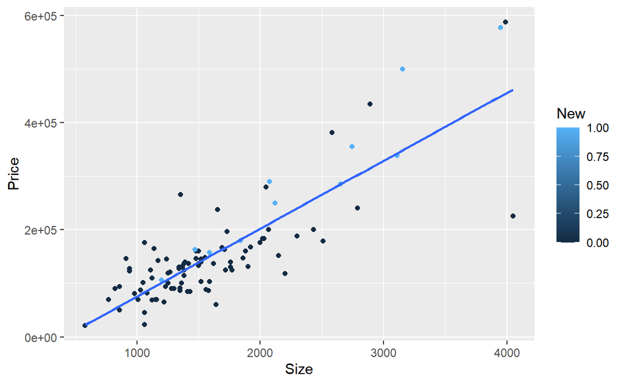

```r
library(ggplot2)

ggplot(data=house.selling.price,aes(x=Size,y=Price, color=New))+
  geom_point()+
  geom_smooth(method="lm",se=F)
```

**F. Find the predicted selling price for a home of 3,000 sqft that is (a) new and (b) not new.**

```r
New_B <-- 22227.81+104.44*3000-78527.50+61.9*3000*1
New_B
```

```
[1] 398264.7
```

The predicted selling price for a New home with the above measurements is $398,264.70.

```r
NotNew_B <--22227.81+104.4*3000
NotNew_B
```

```
[1] 290972.2
```

The predicted selling price for a not-new home with the above measurements is $290,972.20

**G. Find the predicted selling price for a home of 1500 square feet that is (i) new, (ii) not new. Comparing to (F), explain how the difference in predicted selling prices changes as the size of home increases.**

```r
NewC <-- 22227.81+104.4*1500-78527.50+61.9*1500
NewC
```

```
[1] 148694.7
```

The predicted selling price of a new 1500sqft home is $148,694.70

```r
NotNew_C <-- 22227.81+104.4*1500
NotNew_C
```

```
[1] 134372.2
```

The predicted selling price of a 1500sqft home that ISN’T new is $134,372.20

**H. Do you think the model with interaction or the one without it represents the relationship of ‘Size’ and ‘New’ to the outcome price? What makes you prefer one over the other?**

I think a model without interaction would best show the relationship of ‘Size’ and ‘New’ with outcome price; the model with interaction best represents the relationship between ‘Size’ and ‘Price’ rather than ‘Size’ and ‘New’